# Lab04 - Graphical Statistics

Jarad Niemi

2018-01-30

### Setup

To follow along, use the lab04 code also run the following

```r
install.packages("tidyverse")
```

If the install fails, then run

```r
install.packages(c("dplyr","tidyr","ggplot2"))
```

The installation only needs to be done once. But we will need to load the packages in every R session where we want to use them. To load the packages, use

```r
library("dplyr")
library("tidyr")
library("ggplot2")
```

alternatively, you can load the entire (not very big) `tidyverse`.

```r
library("tidyverse")
```

## Constructing plots

The main purpose of the lab today is to construct plots using the `ggplot2` R package. In order to construct these plots, we need to construct an appropriate `data.frame` and we will use `dplyr` to help us construct that `data.frame`.

Let’s use the built-in R data set `airquality`. First, let’s look at the top of the file using the `head()` function.

```r
head(airquality)
```

```
##   Ozone Solar.R Wind Temp Month Day
## 1    41     190  7.4   67     5   1
## 2    36     118  8.0   72     5   2
## 3    12     149 12.6   74     5   3
## 4    18     313 11.5   62     5   4
## 5    NA      NA 14.3   56     5   5
## 6    28      NA 14.9   66     5   6
```

We can get more information, by going to the help file

```r
?airquality
```

One issue with this dataset is that the Month/Day columns don’t really provide us with a `Date`. Let’s create a new column that creates a real `Date`.

```r
airquality <- airquality %>%
  mutate(Date = as.Date(paste("1973",Month,Day,sep="/")))
```

### Histogram

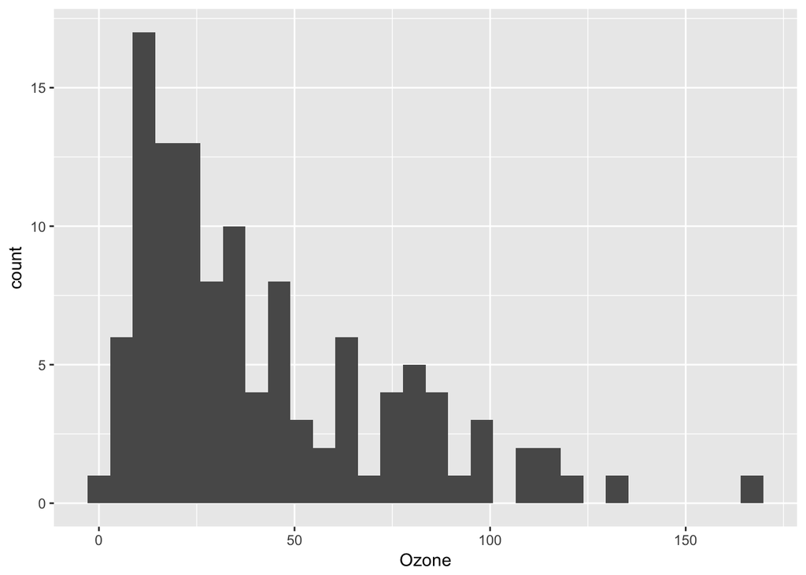

```r
ggplot(airquality,     # data.frame containing the data
       aes(x=Ozone)) + # a column name from the data.frame
  geom_histogram()     # create a histogram
```

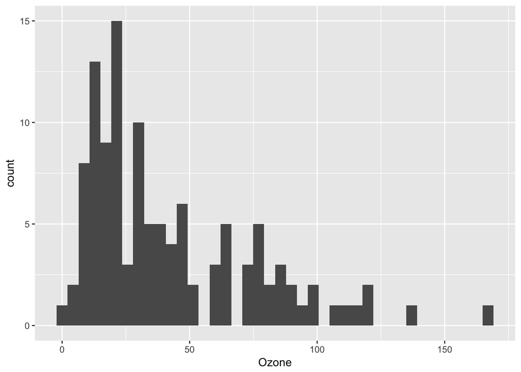

```r
ggplot(airquality, aes(x=Ozone)) +
  geom_histogram(bins = 40)
```

If you want plot on the density scale (so that you can compare to a pdf), use the following:

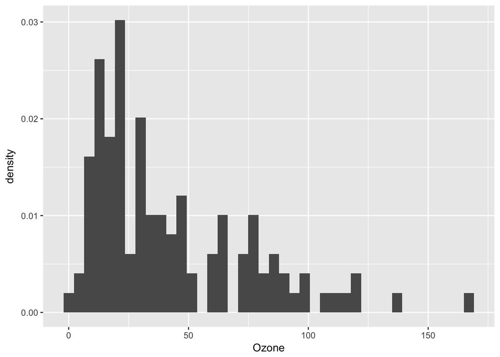

```r
ggplot(airquality, aes(x=Ozone)) +
  geom_histogram(aes(y=..density..), bins = 40)
```

#### Histogram activity

Create a histogram of solar radiation on the density scale with 50 bins.

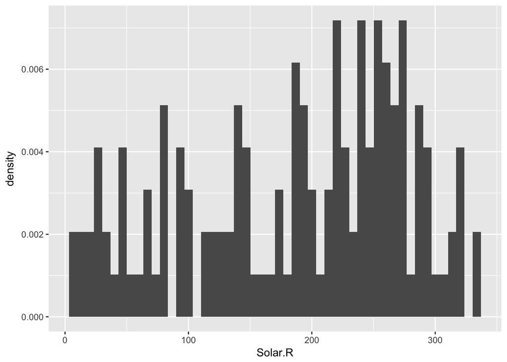

```r
ggplot(airquality, aes(x=Solar.R)) +
  geom_histogram(aes(y=..density..), bins = 50)
```

### Boxplots

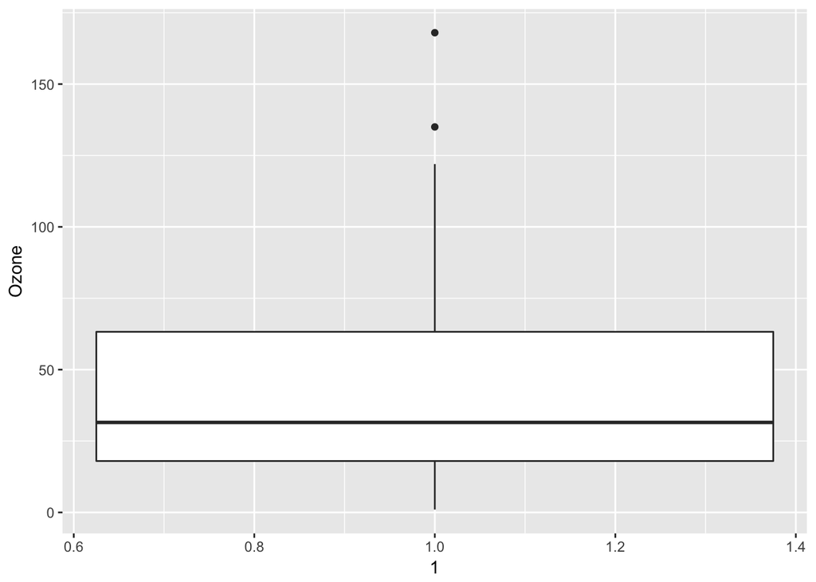

```r
ggplot(airquality,
       aes(x=1,y=Ozone)) +
  geom_boxplot()
```

Comparing boxplots

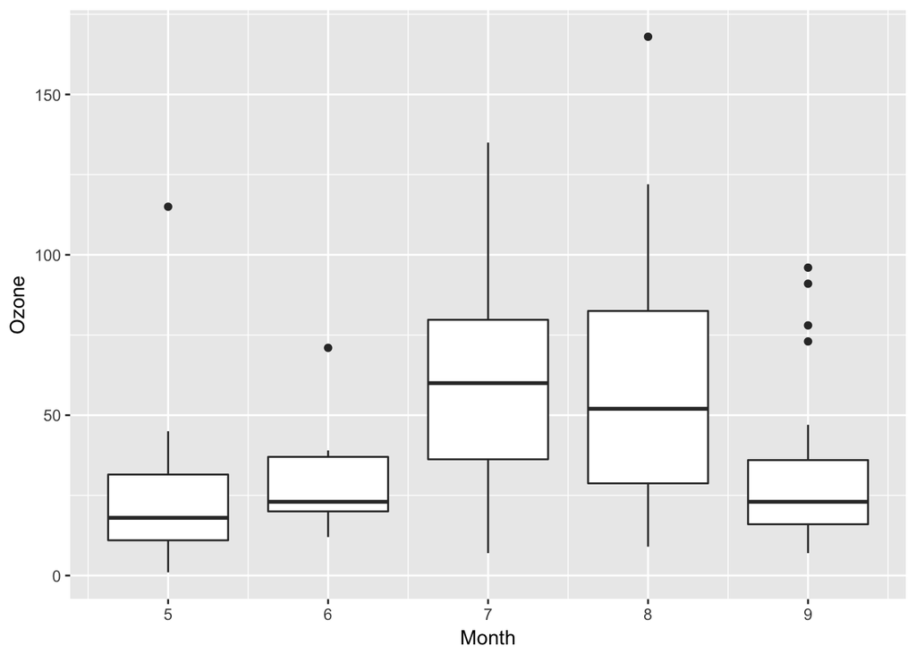

```r
ggplot(airquality,
       aes(x=Month, y=Ozone, group=Month)) +
  geom_boxplot()
```

Add all points to the boxplot

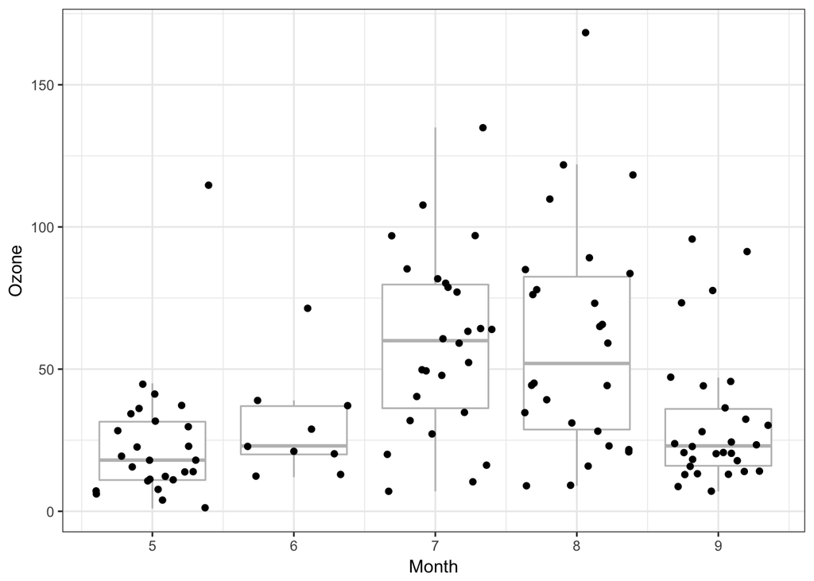

```r
ggplot(airquality,
       aes(x=Month, y=Ozone, group=Month)) +
  geom_boxplot(color='grey',                 # make the boxes not so obvious
               outlier.shape = NA) +         # remove outliers,
  geom_jitter() +                            # because they get plotted here
  theme_bw()
```

#### Boxplot activity

Create a boxplot of wind speed by month.

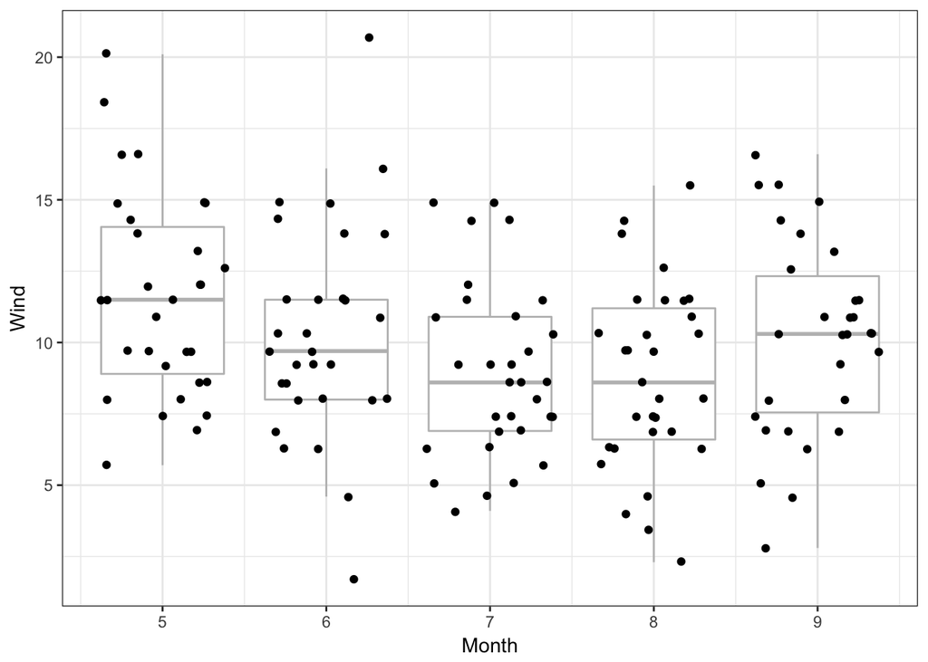

```r
ggplot(airquality,
       aes(x=Month, y=Wind, group=Month)) +
  geom_boxplot(outlier.shape = NA, color='grey') +
  geom_jitter() +
  theme_bw()
```

### Scatterplot

At this point we can construct individual graphs for our 4 different response variables: Ozone, Solar.R, Wind, and Temp. Perhaps we want to understand the temporal variability for Ozone. We can use a scatterplot of Ozone vs Date.

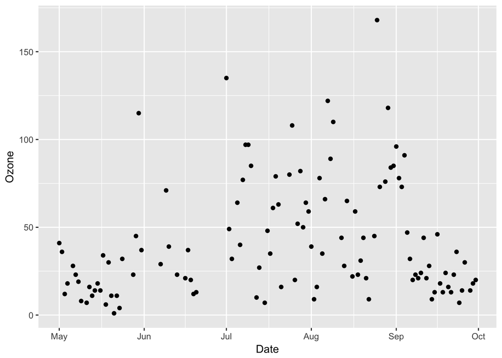

```r
ggplot(airquality, aes(x = Date, y = Ozone)) +
  geom_point()
```

or if we wanted a line plot

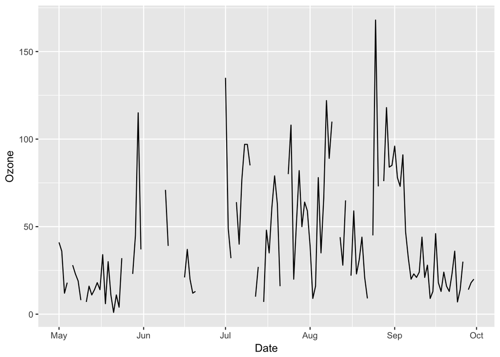

```r
ggplot(airquality, aes(x = Date, y = Ozone)) +
  geom_line()
```

Perhaps we want to understand the relationship between solar radiation and ozone.

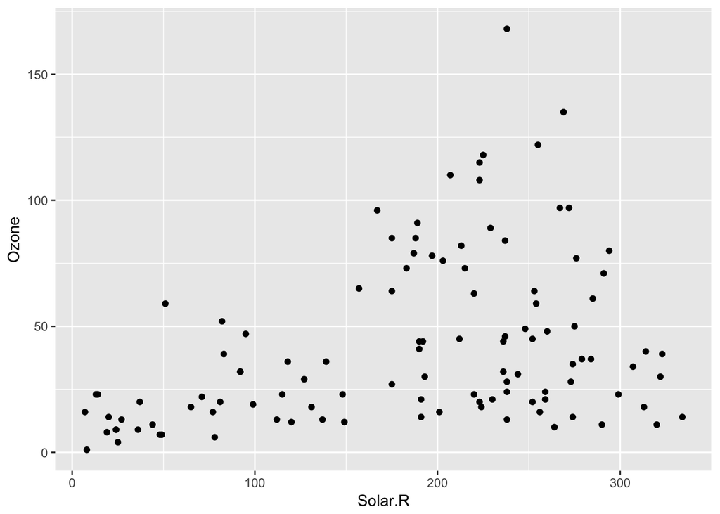

```r
ggplot(airquality, aes(x = Solar.R, y = Ozone)) +
  geom_point()
```

#### Scatterplot activity

Create a scatterplot of wind speed and temperature.

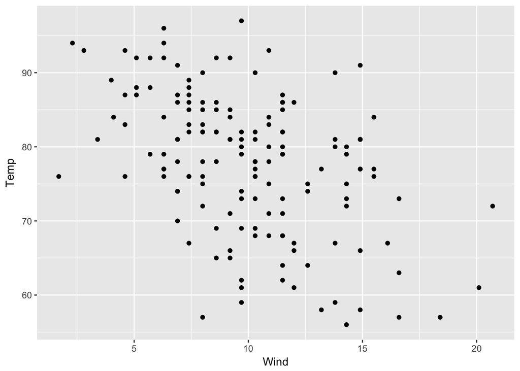

```r
ggplot(airquality, aes(x = Wind, y = Temp)) +
  geom_point()
```

### Faceted scatterplots

What if we want to visualize all 4 response variables vs Date simultaneously. One way to do this is with facets, but in order to use facets, we will need to organize our `data.frame` into long format.

```r
airquality_long <- airquality %>%
  select(-Month, -Day) %>%              # Remove these columns
  tidyr::gather(response, value, -Date)
```

Take a look at the resulting `data.frame`.

```r
dim(airquality)
```

```
## [1] 153   7
```

```r
dim(airquality_long)
```

```
## [1] 612   3
```

```r
head(airquality_long)
```

```
##         Date response value
## 1 1973-05-01    Ozone    41
## 2 1973-05-02    Ozone    36
## 3 1973-05-03    Ozone    12
## 4 1973-05-04    Ozone    18
## 5 1973-05-05    Ozone    NA
## 6 1973-05-06    Ozone    28
```

```r
summary(airquality_long)
```

```
##       Date              response             value
##  Min.   :1973-05-01   Length:612         Min.   :  1.00
##  1st Qu.:1973-06-08   Class :character   1st Qu.: 13.00
##  Median :1973-07-16   Mode  :character   Median : 66.00
##  Mean   :1973-07-16                      Mean   : 80.06
##  3rd Qu.:1973-08-23                      3rd Qu.: 91.00
##  Max.   :1973-09-30                      Max.   :334.00
##                                          NA's   :44
```

```r
table(airquality_long$response)
```

```
##
##   Ozone Solar.R    Temp    Wind
##     153     153     153     153
```

Now we can facet by `response`.

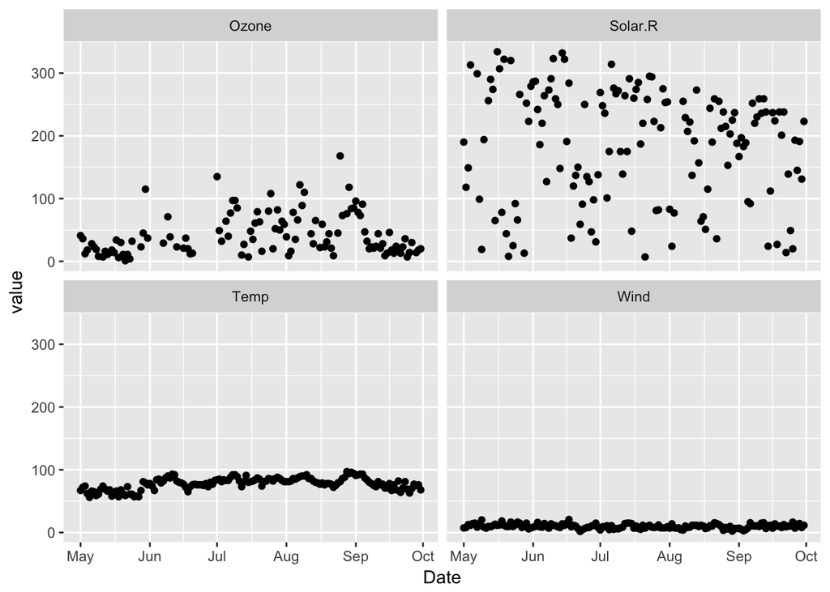

```r
ggplot(airquality_long, aes(Date, value)) +
  geom_point() +
  facet_wrap(~response)
```

Since the axes are quite different for the different responses, we can allow them to vary in the different facets.

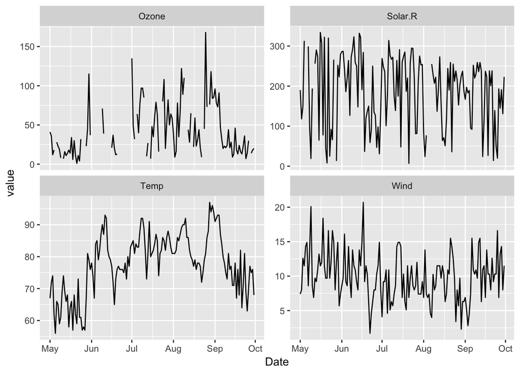

```r
ggplot(airquality_long, aes(Date, value)) +
  geom_line() +
  facet_wrap(~response,scales="free_y")
```

Alternatively (especially if the response variables are on the same scale) we can plot them on the same axes and color them.

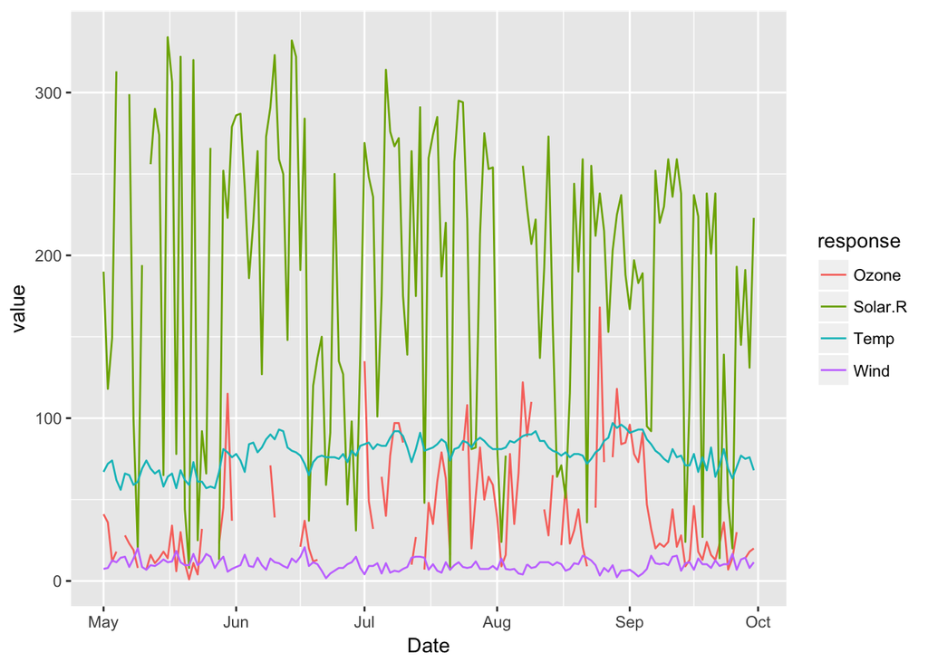

```r
ggplot(airquality_long,
       aes(Date, value, color = response, group = response)) +
  geom_line()
```

Notice that the legend is automatically created. This is not something that is done in base R graphics.

Honestly, this doesn’t look very good, so it is better to just facet the plot.

### Customizing

If we only had the long version of the `data.frame`, we can reconstruct the wide version by using the following

```r
airquality2 <- airquality_long %>%
  tidyr::spread(response, value)
```

Sometimes it is helpful to save the plot so that it can be updated in the future. To save the plot, just use the assignment operator, e.g.

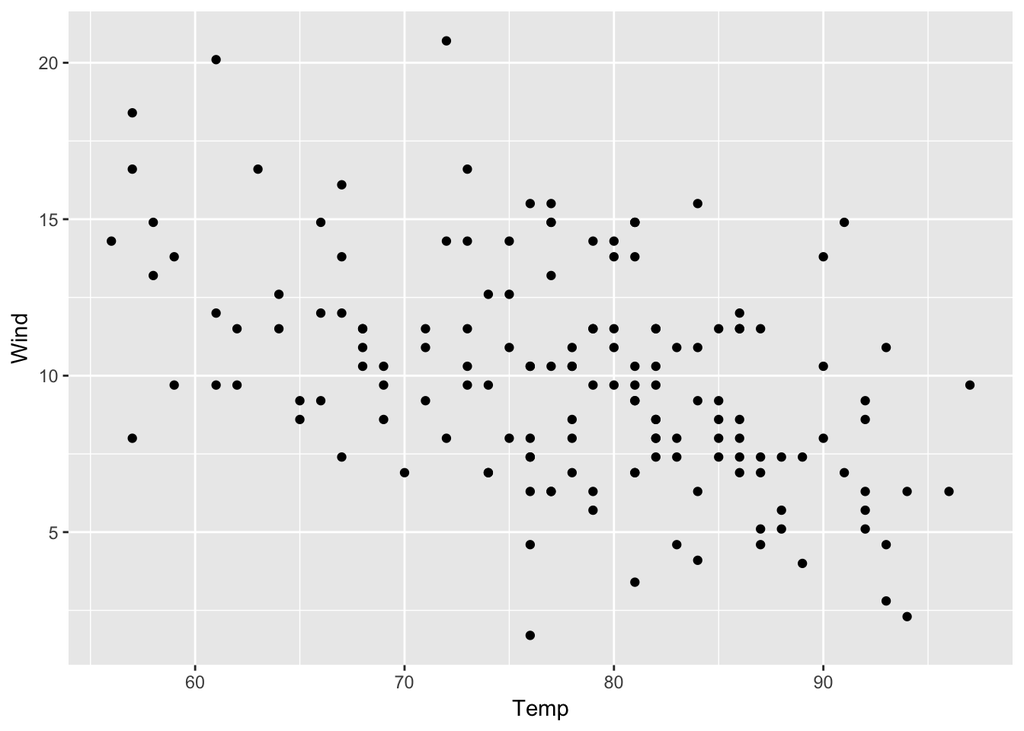

```r
g <- ggplot(airquality2,
       aes(x = Temp, y = Wind)) +
  geom_point()

g # Then you can see the plot by just typing the object name
```

We would like this plot to be a bit more informative, so we will add some informative labels.

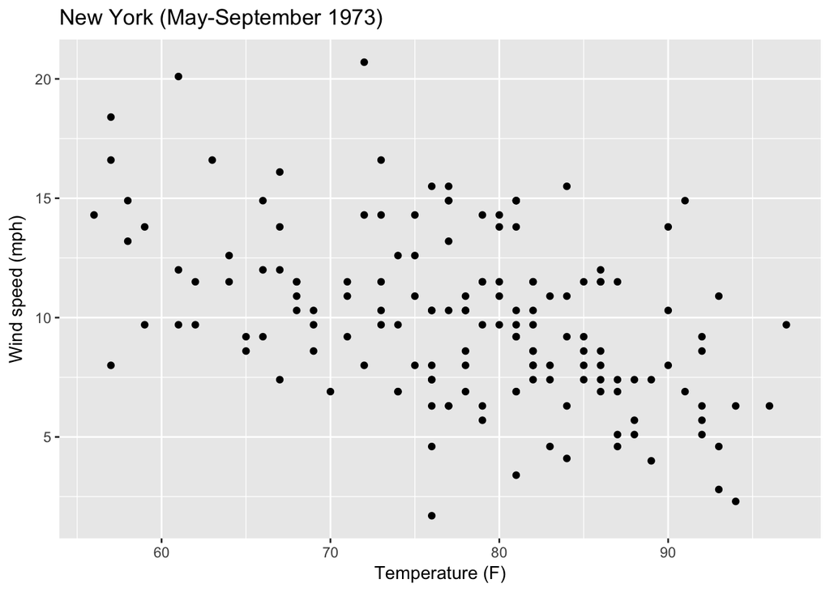

```r
g <- g +
  labs(x = "Temperature (F)",
       y = "Wind speed (mph)",
       title = "New York (May-September 1973)")

g
```

As you have seen before, we can also change the theme. I prefer the simple “bw” theme.

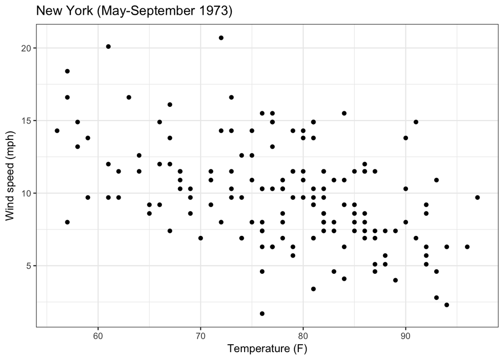

```r
g <- g + theme_bw()
g
```

We can add a regression line.

```r
g <- g + geom_smooth(method="lm")
```

Alternatively, you can combine all the steps

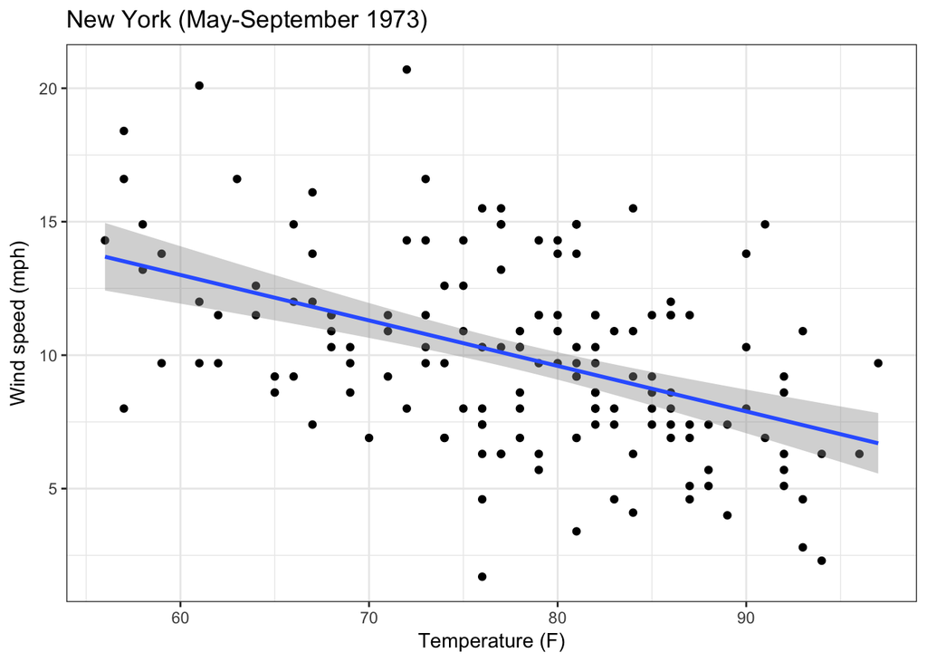

```r
ggplot(airquality2,
       aes(x = Temp, y = Wind)) +
  geom_point() +
  geom_smooth(method = "lm") +
  labs(x = "Temperature (F)",
       y = "Wind speed (mph)",
       title = "New York (May-September 1973)") +
  theme_bw()
```

#### Plot creation activity

Use the `cars` dataset to construct and customize a figure displaying the relationship between the stopping distance and speed of a car.

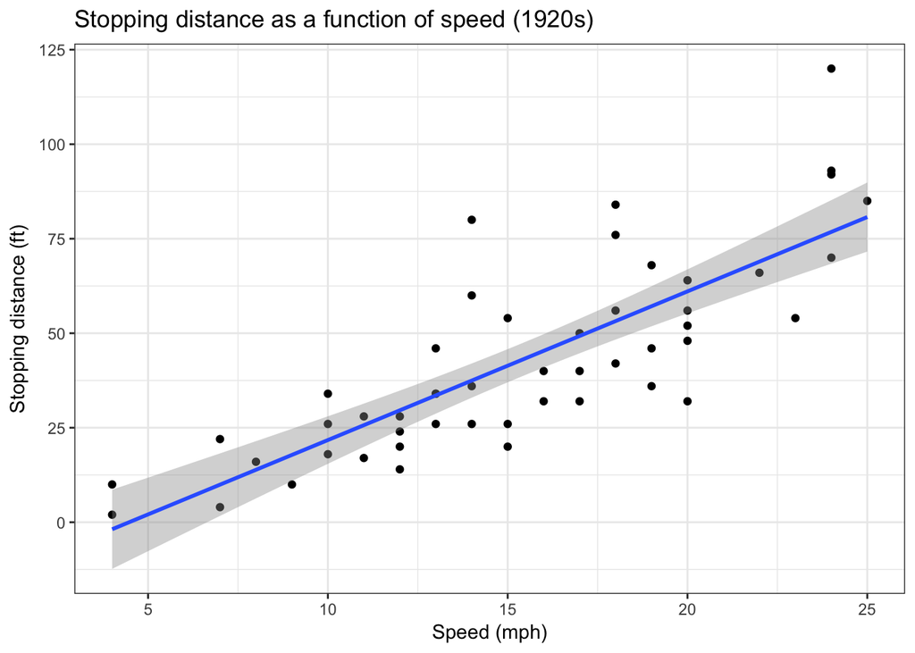

```r
ggplot(cars,
       aes(x=speed, y=dist)) +
  geom_point() +
  geom_smooth(method = "lm") +
  labs(x = "Speed (mph)",
       y = "Stopping distance (ft)",
       title = "Stopping distance as a function of speed (1920s)") +
  theme_bw()
```